# Homework 4

Zinnia Nie

## Problems

### 1

Suppose you have a random variable $X \sim \text{Binomial}(120, 0.15)$.

#### 1A

Calculate and report the mean and standard deviation of the distribution.

```r
# insert code below
120*0.15 # mean
```

```
## [1] 18
```

```r
sqrt(120*0.15*(1-0.15)) # sd
```

```
## [1] 3.911521
```

Mean: **18**

Standard Deviation: **3.911521**

#### 1B

Calculate and report the probability that X=20, $P(X = 20)$.

```r
# insert code below
dbinom(20, 120, 0.15)
```

```
## [1] 0.08570049
```

$P(X = 20)$ = **0.08570049**

#### 1C

Calculate and report the probability that X>=20, $P(X >= 20)$.

```r
# insert code below
pbinom(19, 120, 0.15, lower.tail=FALSE)
```

```
## [1] 0.3413833
```

```r
pbinom(20, 120, 0.15, lower.tail=FALSE) + dbinom(20, 120, 0.15)
```

```
## [1] 0.3413833
```

```r
sum(dbinom(20:120, 120, 0.15))
```

```
## [1] 0.3413833
```

$P(X >= 20)$ = **0.3413833**

#### 1D

Create a graph which displays the binomial distribution of X using vertical segments at each value of X=x, where the height of the segments indicate the probability P(X=x).

- For X >= 20, use a different color for the segments from the rest to help visualize your answer to 1C.
- Only display values on the plot for X <= 50
- You may use functions from `ggprob.R`, or create the graphic using your own code.

(If you want to use `ggprob.R` functions, see discussion 4 file for more specific hints and guidance on the functions.)

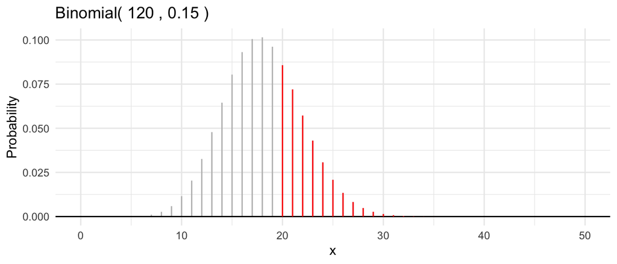

```r
# insert code below
gbinom(120, 0.15, b=50, color="gray") +
  geom_binom_density(120, 0.15, a=20, b=50, color="red") +
  theme_minimal()
```

### 2

What is the probability that $X$ from Question 1 is within one, two, and three standard deviations of the mean? Round each probability to four decimal places.

```r
# insert code below
# mean = 18
# sd = 3.911521

# one sd
#18-3.911521=14.08848 -> 15
#18+3.911521=21.91152 -> 21
sum(dbinom(15:21, 120, 0.15))
```

```
## [1] 0.629428
```

```r
# two sd
#18-2*3.911521=10.17696 -> 11
#18+2*3.911521=25.82304 -> 25
sum(dbinom(11:25, 120, 0.15))
```

```
## [1] 0.946298
```

```r
# three sd
#18-3*3.911521=6.265437 -> 7
#18+3*3.911521=29.73456 -> 29
sum(dbinom(7:29, 120, 0.15))
```

```
## [1] 0.9966266
```

### 3

Draw a graph of the binomial distribution from Questions 1 and 2 (similar to what you did in Question 1D with the vertical segments). You may use functions from `ggprob.R`, or create the graphic using your own code. Only display values for X between 5 and 35.

Add vertical lines with different line types at the end points of the intervals 1, 2, and 3 sigma from the mean:

- solid for $\mu \pm \sigma$
- dashed for $\mu \pm 2\sigma$
- dotted for $\mu \pm 3\sigma$

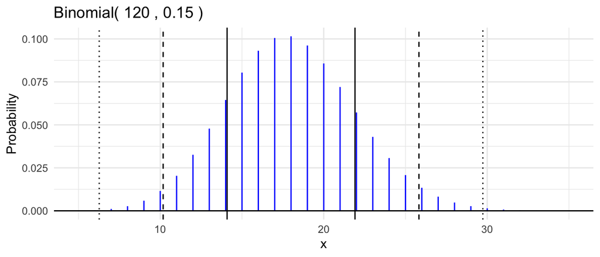

```r
# insert code below
gbinom(120, 0.15, a=5, b=35) +
  geom_vline(xintercept = 18 + c(-1,1)*3.911521) +
  geom_vline(xintercept = 18 + c(-2,2)*3.911521, linetype="dashed") +
  geom_vline(xintercept = 18 + c(-3,3)*3.911521, linetype="dotted") +
  theme_minimal()
```

### 4

#### 4A

Suppose you are playing a coin flipping game with a friend, where you suspect the coin your friend provided is not a fair coin. In fact, you think the probability the coin lands heads is less than 0.5. To test this, you flip the coin 100 times and observe the coin lands heads 35 times. If you assume the coin is fair (i.e., the probability of the coin landing heads is 0.5), what is the probability of observing 35 heads or fewer?

```r
# insert code below
pbinom(35, 100, 0.5)
```

```
## [1] 0.001758821
```

$P(X <= 35)$ = **0.001758821**

#### 4B

> There is evidence against the coin being fair. If the coin was fair, there is an extremely low chance of getting only 35 heads out of 100 trials. Since the chance of a result this extreme occuring is very low, there is a lot of evidence against the coin being fair.

### 5

#### 5A

Create a tibble where each row corresponds to a binomial distribution with the following columns:

- `n` for $n = 1000,1005,1010, 1015, \ldots, 25,000$
- `p` equal to 0.25 for each row
- `mu` equal to the mean
- `sigma` equal to the standard deviation
- `q.90` equal to the 0.90 quantile of the distribution
- `z = (q.90 - mu)/sigma`, the standardized z-score of the quantile
- `prob` equal to $P(X \ge q.90)$, a right-tail probability for the distribution in each row

Display all columns and the rows of this table for which $n$ is a multiple of 5000.

```r
# insert code below
data <- data.frame(n=seq(1000, 25000, 5), p=0.25)

data$mu <- data$n*data$p
data$sigma <- sqrt(data$n*data$p*(1-data$p))

data$q.90 <- qbinom(0.90, data$n, data$p)
data$z <- (data$q.90-data$mu)/data$sigma

data$prob <- pbinom(data$q.90-1, data$n, data$p, lower.tail=FALSE)

head(data, 10)
```

```
##       n    p     mu    sigma q.90        z      prob
## 1  1000 0.25 250.00 13.69306  268 1.314534 0.1012657
## 2  1005 0.25 251.25 13.72725  269 1.293048 0.1050482
## 3  1010 0.25 252.50 13.76136  270 1.271677 0.1089122
## 4  1015 0.25 253.75 13.79538  271 1.250419 0.1128572
## 5  1020 0.25 255.00 13.82932  273 1.301583 0.1034746
## 6  1025 0.25 256.25 13.86317  274 1.280371 0.1072681
## 7  1030 0.25 257.50 13.89694  275 1.259270 0.1111416
## 8  1035 0.25 258.75 13.93063  277 1.310063 0.1019286
## 9  1040 0.25 260.00 13.96424  278 1.289007 0.1056535
## 10 1045 0.25 261.25 13.99777  279 1.268059 0.1094571
```

```r
data %>% filter(n %% 5000 == 0)
```

```
##       n    p   mu    sigma q.90        z      prob
## 1  5000 0.25 1250 30.61862 1289 1.273735 0.1045829
## 2 10000 0.25 2500 43.30127 2556 1.293265 0.1001843
## 3 15000 0.25 3750 53.03301 3818 1.282220 0.1017164
## 4 20000 0.25 5000 61.23724 5079 1.290065 0.1000907
## 5 25000 0.25 6250 68.46532 6338 1.285322 0.1007558
```

#### 5B

Use a line plot to show the relationship between $n$ on the x axis and $z$ on the y axis. Add a smooth curve to highlight the trend. Describe the pattern you see.

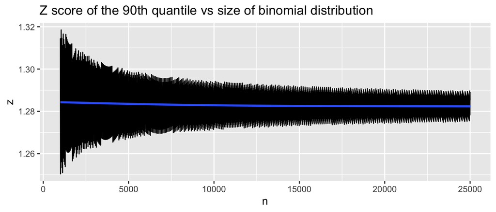

```r
# insert code below
ggplot(data=data, mapping = aes(x=n, y=z)) +
  geom_line() +
  geom_smooth(se=FALSE) +
  ggtitle("Z score of the 90th quantile vs size of binomial distribution")
```

As the number of trials in the binomial distributions increases, the spread of the z-score values becomes smaller. The z values oscillates around about 1.28, however the smooth trend of z-scores also slightly decreases as n increases.

#### 5C

What is the average of the values of $z$ for $n > 15,000$?

```r
# insert code below
data %>% filter(n > 15000) %>% summarise(mean_z = mean(z))
```

```
##     mean_z
## 1 1.282477
```

The mean z-score for $n > 15,000$ is **1.282477**.

#### 5D

Plot the right tail probability `prob` on y axis versus `n` on the x axis.

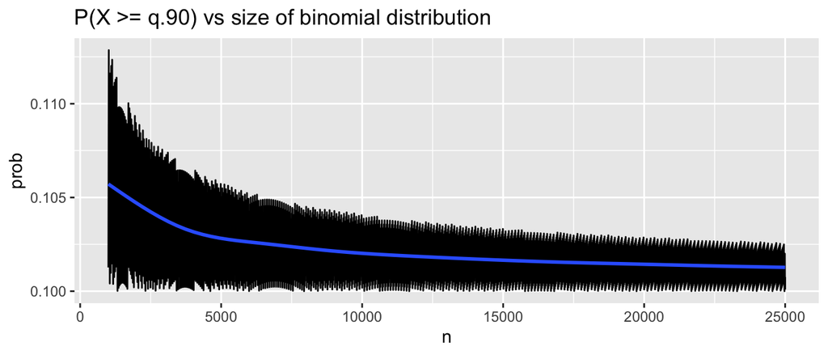

```r
# insert code below
ggplot(data=data, mapping = aes(x=n, y=prob)) +
  geom_line() +
  geom_smooth(se=FALSE) +
  ggtitle("P(X >= q.90) vs size of binomial distribution")
```

As the number of trials increases, the probability of the value of X being grater than the 90th percentile decreases at a decreasing rate. The smooth line approaches 0.1 and the trend is non linear.

#### 5E

What is the average of the values of `prob` for $n > 15,000$?

```r
# insert code below
data %>% filter(n > 15000) %>% summarise(mean_prob = mean(prob))
```

```
##   mean_prob
## 1 0.1014403
```

The mean probability of $P(X \ge q.90)$ is **0.1014403**.